# R Notebook

Load libraries first

```r
library(dplyr)
library(lubridate)
library(tidyverse)
library(tsibble)
library(tsibbledata)
library(feasts)
```

Create vectors

```r
date1 <- ymd_hms("2017-04-22 22:01:18")
date2 <- ymd_hms("2001-11-07 10:09:56")
```

Also need nycflights data

```r
library(nycflights13)
```

Question 1

Extract the different components (year, month, mday, yday, wday) from the variable date1. Add the labels to the month and do not abbreviate the month labels.

```r
year(date1)
```

```
[1] 2017
```

```r
month(date1, label = TRUE, abbr = FALSE)
```

```
[1] April
12 Levels: January < February < March < April < May < June < July < August < September < ... < December
```

```r
mday(date1)
```

```
[1] 22
```

```r
yday(date1)
```

```
[1] 112
```

```r
wday(date1, label = TRUE, abbr = FALSE)
```

```
[1] Saturday
Levels: Sunday < Monday < Tuesday < Wednesday < Thursday < Friday < Saturday
```

```r
hour(date1)
```

```
[1] 22
```

```r
minute(date1)
```

```
[1] 1
```

```r
second(date1)
```

```
[1] 18
```

Question 2

Add 14 days to your date1 variable and store it in a variable called next_fortnight. Take away 10 years from your date2 variable, and store it in previous_decade.

```r
next_fortnight <- date1 + days(14)
next_fortnight
```

```
[1] "2017-05-06 22:01:18 UTC"
```

```r
previous_decade <- date2 - years(10)
previous_decade
```

```
[1] "1991-11-07 10:09:56 UTC"
```

Question 3

Create a variable called this_year which contains today’s date. Then create an interval object which uses this_year and the previous_decade variable you made above. Store it in interval_years. Hint: you’ll need to use lubridate::interval in order to get the right function, as tsibble has one too

```r
this_year <- as_date(now())
interval_years <- this_year - years(10)
interval_years
```

```
[1] "2010-08-11"
```

```r
this_year
```

```
[1] "2020-08-11"
```

Question 4

Change the time zone of both your date variables to “America/New_York”, and call them nyc_date1 and nyc_date2.

pct_date <- with_tz(utc_date, tzone = “Pacific/Auckland”)

```r
nyc_date1 <- with_tz(this_year, tz = "America/New_York")
nyc_date1
```

```
[1] "2020-08-10 20:00:00 EDT"
```

```r
nyc_date2 <- with_tz(interval_years, tz = "America/New_York")
nyc_date2
```

```
[1] "2010-08-10 20:00:00 EDT"
```

Question 5

Use the flights data from the nycflights13 dataset. Make a date-time column called departure_date from the year, month, day, hour, and minute variables in the flights tibble.

```r
glimpse(flights)
```

```
Rows: 336,776
Columns: 19
$ year           <int> 2013, 2013, 2013, 2013, 2013, 2013, 2013, 2013, 2013, 2…
$ month          <int> 1, 1, 1, 1, 1, 1, 1, 1, 1, 1, 1, 1, 1, 1, 1, 1, 1, 1, 1…
$ day            <int> 1, 1, 1, 1, 1, 1, 1, 1, 1, 1, 1, 1, 1, 1, 1, 1, 1, 1, 1…
$ dep_time       <int> 517, 533, 542, 544, 554, 554, 555, 557, 557, 558, 558, …
$ sched_dep_time <int> 515, 529, 540, 545, 600, 558, 600, 600, 600, 600, 600, …
$ dep_delay      <dbl> 2, 4, 2, -1, -6, -4, -5, -3, -3, -2, -2, -2, -2, -2, -1…
$ arr_time       <int> 830, 850, 923, 1004, 812, 740, 913, 709, 838, 753, 849,…
$ sched_arr_time <int> 819, 830, 850, 1022, 837, 728, 854, 723, 846, 745, 851,…
$ arr_delay      <dbl> 11, 20, 33, -18, -25, 12, 19, -14, -8, 8, -2, -3, 7, -1…
$ carrier        <chr> "UA", "UA", "AA", "B6", "DL", "UA", "B6", "EV", "B6", "…
$ flight         <int> 1545, 1714, 1141, 725, 461, 1696, 507, 5708, 79, 301, 4…
$ tailnum        <chr> "N14228", "N24211", "N619AA", "N804JB", "N668DN", "N394…
$ origin         <chr> "EWR", "LGA", "JFK", "JFK", "LGA", "EWR", "EWR", "LGA",…
$ dest           <chr> "IAH", "IAH", "MIA", "BQN", "ATL", "ORD", "FLL", "IAD",…
$ air_time       <dbl> 227, 227, 160, 183, 116, 150, 158, 53, 140, 138, 149, 1…
$ distance       <dbl> 1400, 1416, 1089, 1576, 762, 719, 1065, 229, 944, 733, …
$ hour           <dbl> 5, 5, 5, 5, 6, 5, 6, 6, 6, 6, 6, 6, 6, 6, 6, 5, 6, 6, 6…
$ minute         <dbl> 15, 29, 40, 45, 0, 58, 0, 0, 0, 0, 0, 0, 0, 0, 0, 59, 0…
$ time_hour      <dttm> 2013-01-01 05:00:00, 2013-01-01 05:00:00, 2013-01-01 0…
```

```r
flights %>%
  mutate(departure_date = make_datetime(year, month, day, hour, minute))
```

| year | month | day | dep_time | sched_dep_time | dep_delay | arr_time | sched_arr_time | arr_delay | carrier | flight | tailnum | origin | dest | air_time | distance | hour | minute | time_hour | departure_date |
| --- | --- | --- | --- | --- | --- | --- | --- | --- | --- | --- | --- | --- | --- | --- | --- | --- | --- | --- | --- |
| 2013 | 1 | 1 | 517 | 515 | 2 | 830 | 819 | 11 | UA | 1545 | N14228 | EWR | IAH | 227 | 1400 | 5 | 15 | 2013-01-01 05:00:00 | 2013-01-01 05:15:00 |
| 2013 | 1 | 1 | 533 | 529 | 4 | 850 | 830 | 20 | UA | 1714 | N24211 | LGA | IAH | 227 | 1416 | 5 | 29 | 2013-01-01 05:00:00 | 2013-01-01 05:29:00 |
| 2013 | 1 | 1 | 542 | 540 | 2 | 923 | 850 | 33 | AA | 1141 | N619AA | JFK | MIA | 160 | 1089 | 5 | 40 | 2013-01-01 05:00:00 | 2013-01-01 05:40:00 |
| 2013 | 1 | 1 | 544 | 545 | -1 | 1004 | 1022 | -18 | B6 | 725 | N804JB | JFK | BQN | 183 | 1576 | 5 | 45 | 2013-01-01 05:00:00 | 2013-01-01 05:45:00 |
| 2013 | 1 | 1 | 554 | 600 | -6 | 812 | 837 | -25 | DL | 461 | N668DN | LGA | ATL | 116 | 762 | 6 | 0 | 2013-01-01 06:00:00 | 2013-01-01 06:00:00 |
| 2013 | 1 | 1 | 554 | 558 | -4 | 740 | 728 | 12 | UA | 1696 | N39463 | EWR | ORD | 150 | 719 | 5 | 58 | 2013-01-01 05:00:00 | 2013-01-01 05:58:00 |
| 2013 | 1 | 1 | 555 | 600 | -5 | 913 | 854 | 19 | B6 | 507 | N516JB | EWR | FLL | 158 | 1065 | 6 | 0 | 2013-01-01 06:00:00 | 2013-01-01 06:00:00 |
| 2013 | 1 | 1 | 557 | 600 | -3 | 709 | 723 | -14 | EV | 5708 | N829AS | LGA | IAD | 53 | 229 | 6 | 0 | 2013-01-01 06:00:00 | 2013-01-01 06:00:00 |
| 2013 | 1 | 1 | 557 | 600 | -3 | 838 | 846 | -8 | B6 | 79 | N593JB | JFK | MCO | 140 | 944 | 6 | 0 | 2013-01-01 06:00:00 | 2013-01-01 06:00:00 |
| 2013 | 1 | 1 | 558 | 600 | -2 | 753 | 745 | 8 | AA | 301 | N3ALAA | LGA | ORD | 138 | 733 | 6 | 0 | 2013-01-01 06:00:00 | 2013-01-01 06:00:00 |

[output cut: 990 more lines]

Question 6

Start with the weather data from the nycflights13 package. Select all the variables related to temperature, humidity, and precipitation, and pick out the key and index variables. Have a look at your data, and write a small description of the time series you observe.

Here we can see that our data is collected in hourly format, with observations occuring every day.

```r
glimpse(weather)
```

```
Rows: 26,115
Columns: 15
$ origin     <chr> "EWR", "EWR", "EWR", "EWR", "EWR", "EWR", "EWR", "EWR", "EW…
$ year       <int> 2013, 2013, 2013, 2013, 2013, 2013, 2013, 2013, 2013, 2013,…
$ month      <int> 1, 1, 1, 1, 1, 1, 1, 1, 1, 1, 1, 1, 1, 1, 1, 1, 1, 1, 1, 1,…
$ day        <int> 1, 1, 1, 1, 1, 1, 1, 1, 1, 1, 1, 1, 1, 1, 1, 1, 1, 1, 1, 1,…
$ hour       <int> 1, 2, 3, 4, 5, 6, 7, 8, 9, 10, 11, 13, 14, 15, 16, 17, 18, …
$ temp       <dbl> 39.02, 39.02, 39.02, 39.92, 39.02, 37.94, 39.02, 39.92, 39.…
$ dewp       <dbl> 26.06, 26.96, 28.04, 28.04, 28.04, 28.04, 28.04, 28.04, 28.…
$ humid      <dbl> 59.37, 61.63, 64.43, 62.21, 64.43, 67.21, 64.43, 62.21, 62.…
$ wind_dir   <dbl> 270, 250, 240, 250, 260, 240, 240, 250, 260, 260, 260, 330,…
$ wind_speed <dbl> 10.35702, 8.05546, 11.50780, 12.65858, 12.65858, 11.50780, …
$ wind_gust  <dbl> NA, NA, NA, NA, NA, NA, NA, NA, NA, NA, NA, NA, NA, NA, 20.…
$ precip     <dbl> 0, 0, 0, 0, 0, 0, 0, 0, 0, 0, 0, 0, 0, 0, 0, 0, 0, 0, 0, 0,…
$ pressure   <dbl> 1012.0, 1012.3, 1012.5, 1012.2, 1011.9, 1012.4, 1012.2, 101…
$ visib      <dbl> 10, 10, 10, 10, 10, 10, 10, 10, 10, 10, 10, 10, 10, 10, 10,…
$ time_hour  <dttm> 2013-01-01 01:00:00, 2013-01-01 02:00:00, 2013-01-01 03:00…
```

```r
head(weather, 10)
```

| origin | year | month | day | hour | temp | dewp | humid | wind_dir | wind_speed | wind_gust | precip | pressure | visib | time_hour |
| --- | --- | --- | --- | --- | --- | --- | --- | --- | --- | --- | --- | --- | --- | --- |
| EWR | 2013 | 1 | 1 | 1 | 39.02 | 26.06 | 59.37 | 270 | 10.35702 | NA | 0 | 1012.0 | 10 | 2013-01-01 01:00:00 |
| EWR | 2013 | 1 | 1 | 2 | 39.02 | 26.96 | 61.63 | 250 | 8.05546 | NA | 0 | 1012.3 | 10 | 2013-01-01 02:00:00 |
| EWR | 2013 | 1 | 1 | 3 | 39.02 | 28.04 | 64.43 | 240 | 11.50780 | NA | 0 | 1012.5 | 10 | 2013-01-01 03:00:00 |
| EWR | 2013 | 1 | 1 | 4 | 39.92 | 28.04 | 62.21 | 250 | 12.65858 | NA | 0 | 1012.2 | 10 | 2013-01-01 04:00:00 |
| EWR | 2013 | 1 | 1 | 5 | 39.02 | 28.04 | 64.43 | 260 | 12.65858 | NA | 0 | 1011.9 | 10 | 2013-01-01 05:00:00 |
| EWR | 2013 | 1 | 1 | 6 | 37.94 | 28.04 | 67.21 | 240 | 11.50780 | NA | 0 | 1012.4 | 10 | 2013-01-01 06:00:00 |
| EWR | 2013 | 1 | 1 | 7 | 39.02 | 28.04 | 64.43 | 240 | 14.96014 | NA | 0 | 1012.2 | 10 | 2013-01-01 07:00:00 |
| EWR | 2013 | 1 | 1 | 8 | 39.92 | 28.04 | 62.21 | 250 | 10.35702 | NA | 0 | 1012.2 | 10 | 2013-01-01 08:00:00 |
| EWR | 2013 | 1 | 1 | 9 | 39.92 | 28.04 | 62.21 | 260 | 14.96014 | NA | 0 | 1012.7 | 10 | 2013-01-01 09:00:00 |
| EWR | 2013 | 1 | 1 | 10 | 41.00 | 28.04 | 59.65 | 260 | 13.80936 | NA | 0 | 1012.4 | 10 | 2013-01-01 10:00:00 |

```r
weather %>%
  select(origin, temp, dewp, humid, precip, visib)
```

| origin | temp | dewp | humid | precip | visib |
| --- | --- | --- | --- | --- | --- |
| EWR | 39.02 | 26.06 | 59.37 | 0.00 | 10.00 |
| EWR | 39.02 | 26.96 | 61.63 | 0.00 | 10.00 |
| EWR | 39.02 | 28.04 | 64.43 | 0.00 | 10.00 |
| EWR | 39.92 | 28.04 | 62.21 | 0.00 | 10.00 |
| EWR | 39.02 | 28.04 | 64.43 | 0.00 | 10.00 |
| EWR | 37.94 | 28.04 | 67.21 | 0.00 | 10.00 |
| EWR | 39.02 | 28.04 | 64.43 | 0.00 | 10.00 |
| EWR | 39.92 | 28.04 | 62.21 | 0.00 | 10.00 |
| EWR | 39.92 | 28.04 | 62.21 | 0.00 | 10.00 |
| EWR | 41.00 | 28.04 | 59.65 | 0.00 | 10.00 |

[output cut: 990 more lines]

The time based variables are indexed (year, month, day, hour and time_hour, which is a combination of these). I cannot see any key variables (that change with time) related to temperature, humidity, and precipitation. However origin looks like a key variable.

```r
unique(weather$origin)
```

```
[1] "EWR" "JFK" "LGA"
```

Question 7

Change the weather data into a tsibble. Hint, look up in the notes where we suggest using as_tsibble function. You’ll need to define an index and key.

In order to create a time series tibble, remember you need to provide an index and a key. In our case, time_hour is the only column involving a date/date-time, and so this would be our index. A tsibble also requires a key, which defines individual observations that are tracked over time. In this example, the origin variable is the identifier, and therefore is our key. It is important to note that the duo of the index and key uniquely identifies each observation in a valid tsibble.

```r
weather_ts <- weather %>%
  as_tsibble(key = origin, index = time_hour, regular = FALSE)
weather_ts #The data is all about events with irregularly spaced in time, thus specifying regular = FALSE.
```

| origin | year | month | day | hour | temp | dewp | humid | wind_dir | wind_speed | wind_gust | precip | pressure | visib | time_hour |
| --- | --- | --- | --- | --- | --- | --- | --- | --- | --- | --- | --- | --- | --- | --- |
| EWR | 2013 | 1 | 1 | 1 | 39.02 | 26.06 | 59.37 | 270 | 10.35702 | NA | 0.00 | 1012.0 | 10.00 | 2013-01-01 01:00:00 |
| EWR | 2013 | 1 | 1 | 2 | 39.02 | 26.96 | 61.63 | 250 | 8.05546 | NA | 0.00 | 1012.3 | 10.00 | 2013-01-01 02:00:00 |
| EWR | 2013 | 1 | 1 | 3 | 39.02 | 28.04 | 64.43 | 240 | 11.50780 | NA | 0.00 | 1012.5 | 10.00 | 2013-01-01 03:00:00 |
| EWR | 2013 | 1 | 1 | 4 | 39.92 | 28.04 | 62.21 | 250 | 12.65858 | NA | 0.00 | 1012.2 | 10.00 | 2013-01-01 04:00:00 |
| EWR | 2013 | 1 | 1 | 5 | 39.02 | 28.04 | 64.43 | 260 | 12.65858 | NA | 0.00 | 1011.9 | 10.00 | 2013-01-01 05:00:00 |
| EWR | 2013 | 1 | 1 | 6 | 37.94 | 28.04 | 67.21 | 240 | 11.50780 | NA | 0.00 | 1012.4 | 10.00 | 2013-01-01 06:00:00 |
| EWR | 2013 | 1 | 1 | 7 | 39.02 | 28.04 | 64.43 | 240 | 14.96014 | NA | 0.00 | 1012.2 | 10.00 | 2013-01-01 07:00:00 |
| EWR | 2013 | 1 | 1 | 8 | 39.92 | 28.04 | 62.21 | 250 | 10.35702 | NA | 0.00 | 1012.2 | 10.00 | 2013-01-01 08:00:00 |
| EWR | 2013 | 1 | 1 | 9 | 39.92 | 28.04 | 62.21 | 260 | 14.96014 | NA | 0.00 | 1012.7 | 10.00 | 2013-01-01 09:00:00 |
| EWR | 2013 | 1 | 1 | 10 | 41.00 | 28.04 | 59.65 | 260 | 13.80936 | NA | 0.00 | 1012.4 | 10.00 | 2013-01-01 10:00:00 |

[output cut: 990 more lines]

Question 8

Add a year and month column to your new tsibble weather data, and create a basic line plot which shows the temperature data from each airport over time. Have a think back to what you learned in visualisation week, and think about whether plotting the whole time series in one go is adequate here? Write down your suggestions for what could be done to make a better and more informative plot.

```r
new_weather_ts <- weather_ts
mutate(year = lubridate::year(Date))
```

```
Error in as.POSIXlt.default(x, tz = tz(x)) :
  do not know how to convert 'x' to class “POSIXlt”
```

#Cannot add month and year, however not sure why as it is already in the data?

```r
new_weather_ts <- weather_ts
select(year, temp) %>%
index_by(year) %>%
  summarise(mean_temp = mean(temp))
```

```
Error in UseMethod("select_") :
  no applicable method for 'select_' applied to an object of class "function"
```

```r
new_weather_ts <-
  filter(year, temp) %>%
  group_by(origin) %>%
  new_weather_ts
```

```
`filter_()` is deprecated as of dplyr 0.7.0.
Please use `filter()` instead.
See vignette('programming') for more help
  no applicable method for 'filter_' applied to an object of class "function"
```

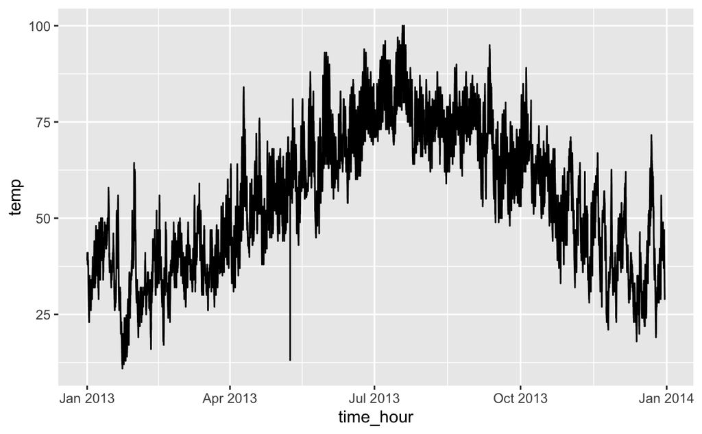

```r
ggplot(data = weather,
       aes(x = time_hour, y = temp)) +
  geom_line()
```

Question 9

Choose an appropriate rolling window and calculate a moving average for your weather temperature data for each airport origin. Create a useful plot which overlays the original time series data and the rolling average data. Make sure the graph is easy for others to understand (Hint: you might want to facet_wrap). Finally, write a summary of why you chose the time window you did, and describe any trends you see.

```r
# calculate a rolling window
weather_rolling <- weather %>%
  group_by_key() %>%
  mutate(temp_ma = slide_dbl(temp, ~ mean)
```

```
Error: Incomplete expression: weather_rolling <- weather >
  group_by_key() >
  mutate(temp_ma = slide_dbl(temp, ~ mean)
```

```r
ggplot(weather_rolling) +
  geom_line(aes(x = time_hour, y = temp), colour = "grey") +
    geom_line(aes(x = time_hour, y = temp), colour = "red")
```

```
Error in ggplot(weather_rolling) : object 'weather_rolling' not found
```

Question 10

Downsample your data so that you plot daily temperature data for each airport, instead of hourly data. #need above code to work for this